# githubpage_test file

Paul Schuette

May 18, 2018

Ctrl-Alt-I is a keyboard shortcut for creating a chunk of r code

```r
  library(leaflet)
  library(dplyr)
  library(tidyr)
  library(ggplot2)
  library(DT)
```

Then, let’s create the data.frame we’re going to use to plot:

```r
esc <- read.csv("data/escapement_counts.csv", stringsAsFactors = FALSE)
```

If you haven’t saved the data locally, you can load it directly from the KNB using this line:

esc <- read.csv(url(“https://knb.ecoinformatics.org/knb/d1/mn/v2/object/knb.92020.1”, method = “libcurl”), stringsAsFactors = FALSE)

```r
esc %>% head()
```

```
##        Location SASAP.Region sampleDate Species DailyCount  Method
## 1 Akalura Creek       Kodiak 1930-05-24 Sockeye          4 Unknown
## 2 Akalura Creek       Kodiak 1930-05-25 Sockeye         10 Unknown
## 3 Akalura Creek       Kodiak 1930-05-26 Sockeye          0 Unknown
## 4 Akalura Creek       Kodiak 1930-05-27 Sockeye          0 Unknown
## 5 Akalura Creek       Kodiak 1930-05-28 Sockeye          0 Unknown
## 6 Akalura Creek       Kodiak 1930-05-29 Sockeye          0 Unknown
##   Latitude Longitude Source
## 1  57.1641 -154.2287   ADFG
## 2  57.1641 -154.2287   ADFG
## 3  57.1641 -154.2287   ADFG
## 4  57.1641 -154.2287   ADFG
## 5  57.1641 -154.2287   ADFG
## 6  57.1641 -154.2287   ADFG
```

Now that we have the data loaded, let’s calculate median annual escapement by species:

```r
median_esc <- esc %>%
  separate(sampleDate, c("Year", "Month", "Day"), sep = "-") %>%
  group_by(Species, SASAP.Region, Year, Location) %>%
  summarize(escapement = sum(DailyCount)) %>%
  group_by(Species) %>%
  summarize(median_escapement = median(escapement))
```

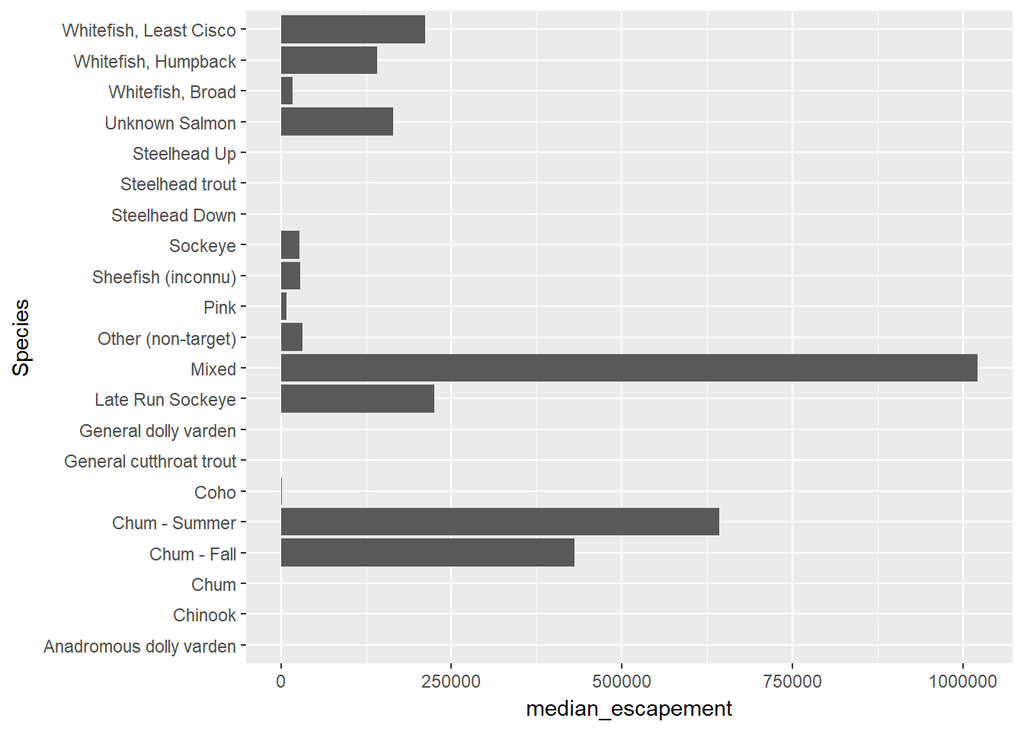

```r
ggplot(median_esc, aes(Species, median_escapement)) +
  geom_col() +
  coord_flip()
```

Calculate median annual escapement by species using the dplyr package Let’s convert the escapement data into a table of just the unique locations:

```r
locations <- esc %>%
  distinct(Location, Latitude, Longitude) %>%
  drop_na()
```

```r
datatable(locations)
```

|  | Location | Latitude | Longitude |
| --- | --- | --- | --- |
| 1 | Akalura Creek | 57.1641 | -154.2287 |
| 4 | Anvik River | 62.7 | -160.2 |
| 6 | Ayakulik River | 57.1956 | -154.529 |
| 7 | Bear Creek | 56.0389 | -160.2734 |
| 8 | Bear River | 56.0389 | -160.2734 |
| 9 | Big Bay Creek | 58.5426 | -152.5683 |
| 10 | Big Kitoi Creek | 58.1915 | -152.3754 |
| 12 | Black Lake | 56.392 | -158.937 |
| 13 | Buskin River | 57.7768 | -152.5372 |
| 14 | Chelatna Lake | 62.4731 | 151.4545 |

[output cut: 58 more lines]

Then making a leaflet map is (generally) only a couple of lines of code:

```r
leaflet(locations) %>%
  addTiles() %>%
  addMarkers(~ Longitude, ~ Latitude, popup = ~ Location)
```

[interactive chart not shown]

When you knit and view the results of this cell locally (on your own computer), you will see a map with icons marking the locations. However, when you push the html to GitHub and view your page there, you’ll see a map with no icons (as of the date of this training). This appears to be due to a certificate issue with server that provides the leaflet icons. There is a workaround, but it adds several more lines of code

# Use a custom marker so Leaflet doesn’t try to grab the marker images from

# its CDN (this was brought up in

# https://github.com/NCEAS/sasap-training/issues/22)

```r
markerIcon <- makeIcon(
  iconUrl = "https://cdnjs.cloudflare.com/ajax/libs/leaflet/1.3.1/images/marker-icon.png",
  iconWidth = 25, iconHeight = 41,
  iconAnchorX = 12, iconAnchorY = 41,
  shadowUrl = "https://cdnjs.cloudflare.com/ajax/libs/leaflet/1.3.1/images/marker-shadow.png",
  shadowWidth = 41, shadowHeight = 41,
  shadowAnchorX = 13, shadowAnchorY = 41
)
```

Do you see all those points way over in Russia? This is an Alaskan data set. Those aren’t supposed to be there. Can you guess why they’re showing up over there? If you glance through the coordinates in the locations table above it should become obvious. Here’s how to fix it:

```r
locs <- locations %>% mutate(Longitude = abs(Longitude) * -1)
leaflet(locs) %>%
  addTiles() %>%
  addMarkers(~ Longitude, ~ Latitude, popup = ~ Location, icon = markerIcon)
```

[interactive chart not shown]